# 20210528_cressie_lattice_cuenca

Guillermina Senn

5/28/2021

```
## This is INLA_21.02.23 built 2021-02-22 21:11:05 UTC.
##  - See www.r-inla.org/contact-us for how to get help.
##  - Save 379.7Mb of storage running 'inla.prune()'
```

```
## To access larger datasets in this package, install the spDataLarge
## package with: `install.packages('spDataLarge',
## repos='https://nowosad.github.io/drat/', type='source')`
```

[output not shown]

```
## GDAL version >= 3.1.0 | setting mapviewOptions(fgb = TRUE)
```

# Capitulo 6: Modelo espaciales sobre grillas

## 1. Cargar y pre-procesar los datos

```r
data_raw <- st_read(
  dsn = '../data/processed/cuenca/cuenca_25.gpkg'
)
data <- data.frame(data_raw)
for (col in names(data)[names(data) != 'geom']){
  data[, col] <- replace(data[, col],
                         (data[, col] == Inf) + (data[, col] == -Inf) > 0,
                         NA)
}
data <- data[data$id_unico < 150, ]
data <- data[!is.na(data$Media_VUT), ]
data <- data[!is.na(data$Media_DEM), ]
st_geometry(data) <- data$geom
```

```r
centroids <- st_centroid(data)
coords <- st_coordinates(centroids$geom)
data$lat <- coords[, 1]
data$lon <- coords[, 2]
```

```r
qtm(data, "Media_ESPI.LTT")
```

```
## Legend labels were too wide. The labels have been resized to 0.39, 0.39, 0.39, 0.39, 0.39, 0.39. Increase legend.width (argument of tm_layout) to make the legend wider and therefore the labels larger.
```

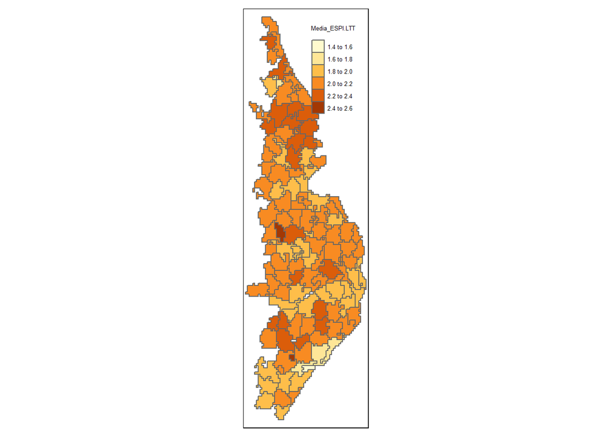

## 2. Exploratory analysis

### 2.1 Spatial EDA

The semivariogram:

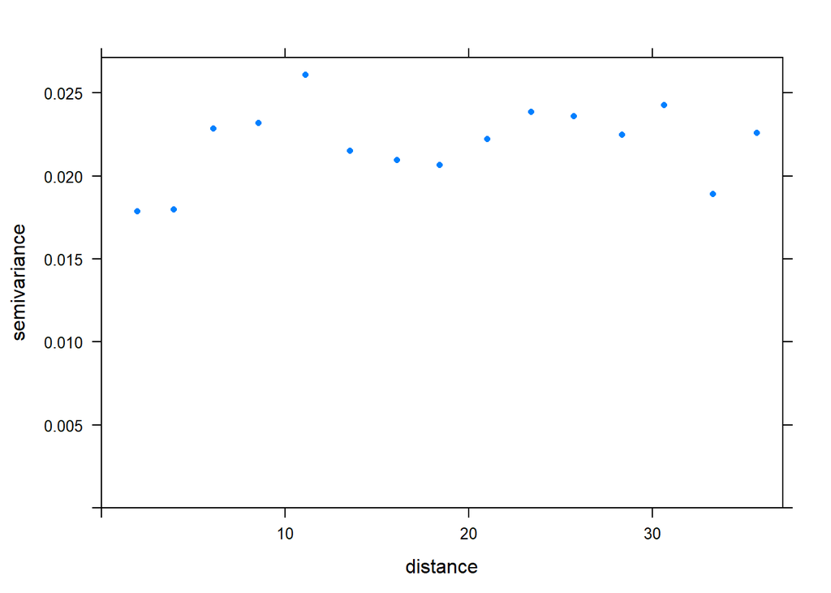

```r
vgm <- variogram(
  object = Media_ESPI.LTT ~ 1,
  data = data
)
plot(vgm, pch = 16, cex = 0.6)
```

El índice de autocorrelación espacial de Moran:

```r
nb <- poly2nb(pl = data, queen = TRUE)
w <- nb2listw(neighbours = nb, style = 'W', zero.policy = TRUE)
imoran <- moran.mc(x = data$Media_ESPI.LTT, listw = w, nsim = 1000,
                   zero.policy = T, na.action = na.omit)
# plot(imoran)
imoran
```

```
##
##  Monte-Carlo simulation of Moran I
##
## data:  data$Media_ESPI.LTT
## weights: w
## number of simulations + 1: 1001
##
## statistic = 0.28, observed rank = 1001, p-value = 0.000999
## alternative hypothesis: greater
```

```r
lm1 <- lm(
  formula = Media_ESPI.LTT ~ Media_DEM + Media_VUT,
  data = data
)
data$res_lm1 <- residuals(lm1)
summary(lm1)
```

```
##
## Call:
## lm(formula = Media_ESPI.LTT ~ Media_DEM + Media_VUT, data = data)
##
## Residuals:
##      Min       1Q   Median       3Q      Max
## -0.60309 -0.10360  0.01180  0.09265  0.45248
##
## Coefficients:
##               Estimate Std. Error t value Pr(>|t|)
## (Intercept)  1.772e+00  1.099e-01  16.118  < 2e-16 ***
## Media_DEM    4.059e-03  1.286e-03   3.156  0.00201 **
## Media_VUT   -1.726e-07  8.510e-08  -2.028  0.04471 *
## ---
## Signif. codes:  0 '***' 0.001 '**' 0.01 '*' 0.05 '.' 0.1 ' ' 1
##
## Residual standard error: 0.1503 on 123 degrees of freedom
## Multiple R-squared:  0.07889,    Adjusted R-squared:  0.06391
## F-statistic: 5.267 on 2 and 123 DF,  p-value: 0.006385
```

```r
imoran <- moran.mc(x = data$res_lm1, listw = w, nsim = 1000,
                   zero.policy = T, na.action = na.omit)
imoran
```

```
##
##  Monte-Carlo simulation of Moran I
##
## data:  data$res_lm1
## weights: w
## number of simulations + 1: 1001
##
## statistic = 0.23465, observed rank = 1001, p-value = 0.000999
## alternative hypothesis: greater
```

```r
qtm(shp = data, fill = 'res_lm1')
```

```
## Variable(s) "res_lm1" contains positive and negative values, so midpoint is set to 0. Set midpoint = NA to show the full spectrum of the color palette.
```

```
## Legend labels were too wide. The labels have been resized to 0.34, 0.34, 0.34, 0.36, 0.39, 0.39, 0.39. Increase legend.width (argument of tm_layout) to make the legend wider and therefore the labels larger.
```

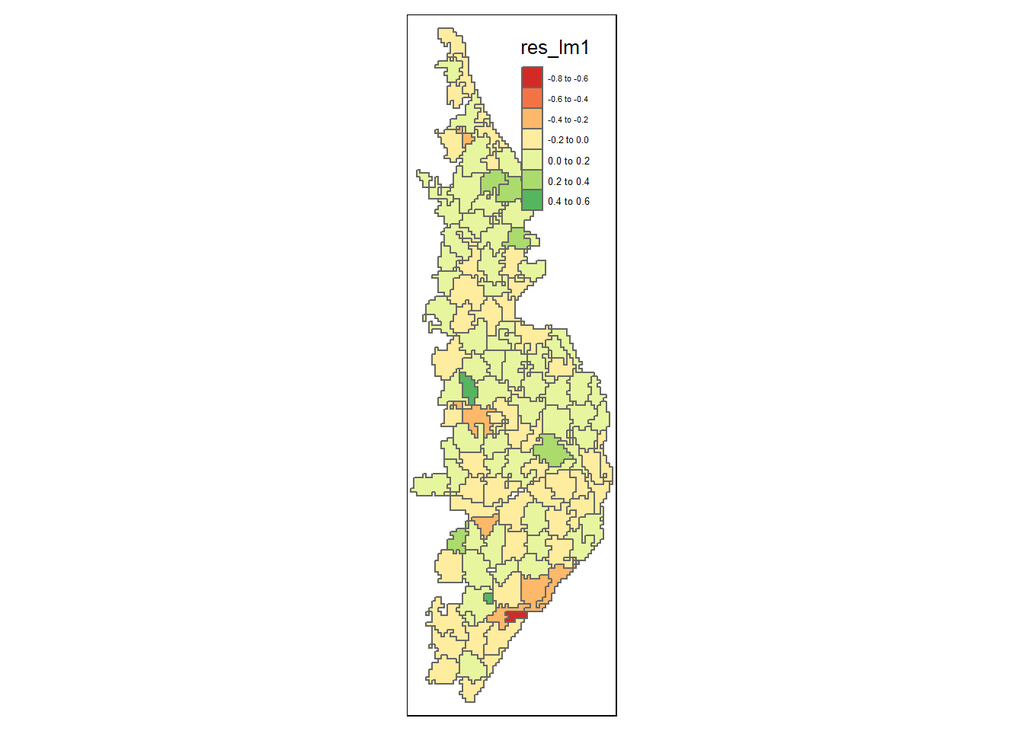

## 3. SAR

El modelo SAR es una regresion lineal

$$Z(s) = X(s)\beta + e(s)$$

donde los errores son los que incorporan la autorregresion espacial, al estar regresionados entre ellos. Su expresion es:

$$e_i = \sum_{i=1}^m{b_{ij}e_i + \varepsilon_i}$$
Otra manera de expresar el modelo, en forma matricial y haciendo explicita la dependencia de los errores, es:

$$(I-B)(Z-X'\beta) = \varepsilon$$
En este modelo: * $Z \sim G(X'\beta, \Sigma_{SAR})$, con $\Sigma_{SAR} = Var(Z) = (I-B)^{-1}\Sigma_{\varepsilon}(I-B')^{-1}$.

- los $\varepsilon_i$ son los errores residuales que se asumen i.i.d. y $N(0, \sigma^2_{\varepsilon_i}I)$. Se pueden modelar homo u heterocedasticamente.
- los $b_{ij}$ son los componentes de la matriz de dependencia espacial entre areas, y los $b_{ii}=0$ para que las areas no se regresionen sobre si mismas. Es muy comun que $B = \lambda W$, donde $\lambda$ es el parametro de autocorrelacion espacial, y $W$ la matriz de dependencia espacial.
- La matriz $(I-B)$ debe ser no singular.

Los modelos SAR se estiman eficientemente con ML con la funcion `spdep::spautolm`, donde la matriz $W$ es un objeto de pesos `listw`. Este comando utiliza ML y no sirve para grandes datasets con miles de observaciones porque usa metodos de matrices densas.

Ajustamos un SAR usando como matriz de vecindad la `w` que calcule antes, con estilo W (normalizado por fila) y definiendo como vecinos con modo reina.

```r
# print(w, zero.policy = TRUE)
sar1 <- spautolm(
  formula = Media_ESPI.LTT ~ Media_DEM + Media_VUT,
  data = data,
  listw = w,
  family = "SAR",
  verbose = TRUE
)
```

[output not shown]

```r
data$res_sar1 <- residuals(sar1)
summary(sar1)
```

```
##
## Call: spautolm(formula = Media_ESPI.LTT ~ Media_DEM + Media_VUT, data = data,
##     listw = w, family = "SAR", verbose = TRUE)
##
## Residuals:
##        Min         1Q     Median         3Q        Max
## -0.4567662 -0.0975835  0.0027815  0.0917478  0.4328002
##
## Coefficients:
##                Estimate  Std. Error z value Pr(>|z|)
## (Intercept)  1.6862e+00  1.5686e-01 10.7497  < 2e-16
## Media_DEM    4.4786e-03  1.8545e-03  2.4150  0.01574
## Media_VUT   -7.7715e-08  1.2255e-07 -0.6341  0.52599
##
## Lambda: 0.48836 LR test value: 15.889 p-value: 6.7164e-05
## Numerical Hessian standard error of lambda: 0.10941
##
## Log likelihood: 69.46271
## ML residual variance (sigma squared): 0.018319, (sigma: 0.13535)
## Number of observations: 126
## Number of parameters estimated: 5
## AIC: -128.93
```

Por otro lado, comparando con la regresión lineal estándar, el intercepto se achicó, el coeficiente de VUT ya no es significativo, y el DEM es mayor en magnitud.

```r
imoran <- moran.mc(x = data$res_sar1, listw = w, nsim = 1000,
                   zero.policy = T, na.action = na.omit)
imoran
```

```
##
##  Monte-Carlo simulation of Moran I
##
## data:  data$res_sar1
## weights: w
## number of simulations + 1: 1001
##
## statistic = 0.0083758, observed rank = 632, p-value = 0.3686
## alternative hypothesis: greater
```

```r
qtm(shp = data, fill = 'res_sar1')
```

```
## Variable(s) "res_sar1" contains positive and negative values, so midpoint is set to 0. Set midpoint = NA to show the full spectrum of the color palette.
```

```
## Legend labels were too wide. The labels have been resized to 0.34, 0.34, 0.36, 0.39, 0.39, 0.39. Increase legend.width (argument of tm_layout) to make the legend wider and therefore the labels larger.
```

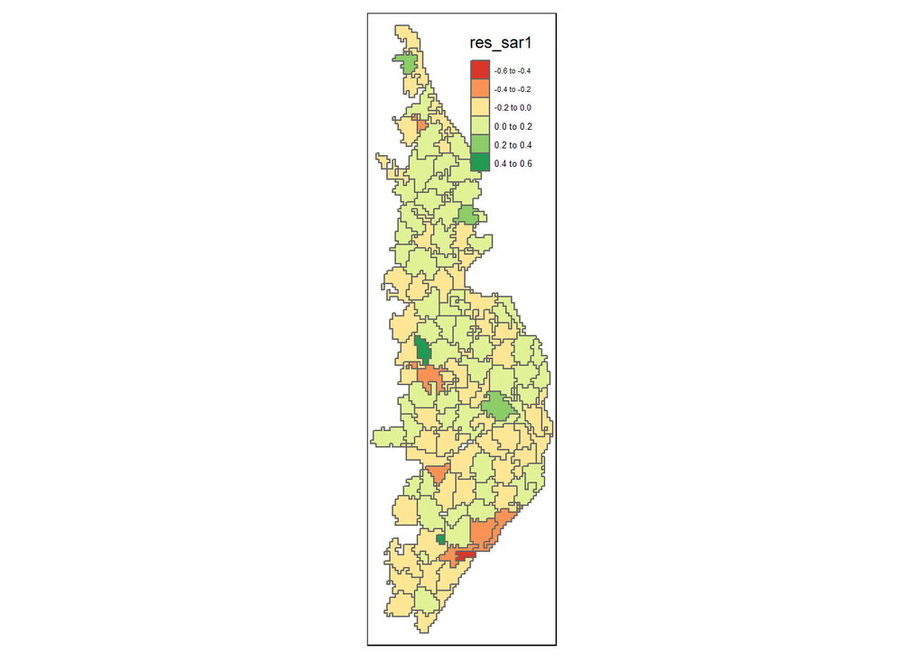

El modelo SAR ha logrado usar la información de la autocorrelación espacial de manera que ya no quede en los residuos.

## 4. CAR

En este caso el modelo se especifica sobre la distribucion *condicional* de los términos de error. Sean $e_{j \sim i}$ los términos de error correspondientes a los vecinos del area $i$. Luego:

$$e_i | e_{j \sim i} \sim N(\sum_{j \sim i}{\frac{c_{ij}e_j}{\sum_{j\sim i}{c_{ij}}}}, \frac{\sigma^2_{e_i}}{\sum_{j\sim i}{c_{ij}}})$$

O sea, los errores condicionales se distribuyen normales, con varianza dada por la varianza en el area normalizada por la suma de los pesos vecinos, y media dada por la media ponderada de los pesos vecinos, normalizada por la suma de los pesos vecinos. Los $c_{ij}$ son similares a los $b_{ij}$.

Ajustemos un modelo CAR.

```r
car1 <- spautolm(
  formula = Media_ESPI.LTT ~ Media_DEM + Media_VUT,
  data = data,
  listw = w,
  family = "CAR",
  verbose = TRUE
)
```

[output not shown]

```r
data$res_car1 <- residuals(car1)
summary(car1)
```

```
##
## Call: spautolm(formula = Media_ESPI.LTT ~ Media_DEM + Media_VUT, data = data,
##     listw = w, family = "CAR", verbose = TRUE)
##
## Residuals:
##        Min         1Q     Median         3Q        Max
## -0.4649153 -0.0864829  0.0062118  0.0886609  0.4412997
##
## Coefficients:
##                Estimate  Std. Error z value Pr(>|z|)
## (Intercept)  1.9422e+00  1.3534e-01 14.3509   <2e-16
## Media_DEM    1.5337e-03  1.5962e-03  0.9609   0.3366
## Media_VUT   -3.7317e-08  1.0669e-07 -0.3498   0.7265
##
## Lambda: 0.54244 LR test value: 9.8216 p-value: 0.0017247
## Numerical Hessian standard error of lambda: 0.24498
##
## Log likelihood: 66.42897
## ML residual variance (sigma squared): 0.019643, (sigma: 0.14015)
## Number of observations: 126
## Number of parameters estimated: 5
## AIC: -122.86
```

```r
imoran <- moran.mc(x = data$res_car1, listw = w, nsim = 1000,
                   zero.policy = T, na.action = na.omit)
imoran
```

```
##
##  Monte-Carlo simulation of Moran I
##
## data:  data$res_car1
## weights: w
## number of simulations + 1: 1001
##
## statistic = -0.013291, observed rank = 440, p-value = 0.5604
## alternative hypothesis: greater
```

```r
qtm(shp = data, fill = 'res_car1')
```

```
## Variable(s) "res_car1" contains positive and negative values, so midpoint is set to 0. Set midpoint = NA to show the full spectrum of the color palette.
```

```
## Legend labels were too wide. The labels have been resized to 0.34, 0.34, 0.36, 0.39, 0.39, 0.39. Increase legend.width (argument of tm_layout) to make the legend wider and therefore the labels larger.
```

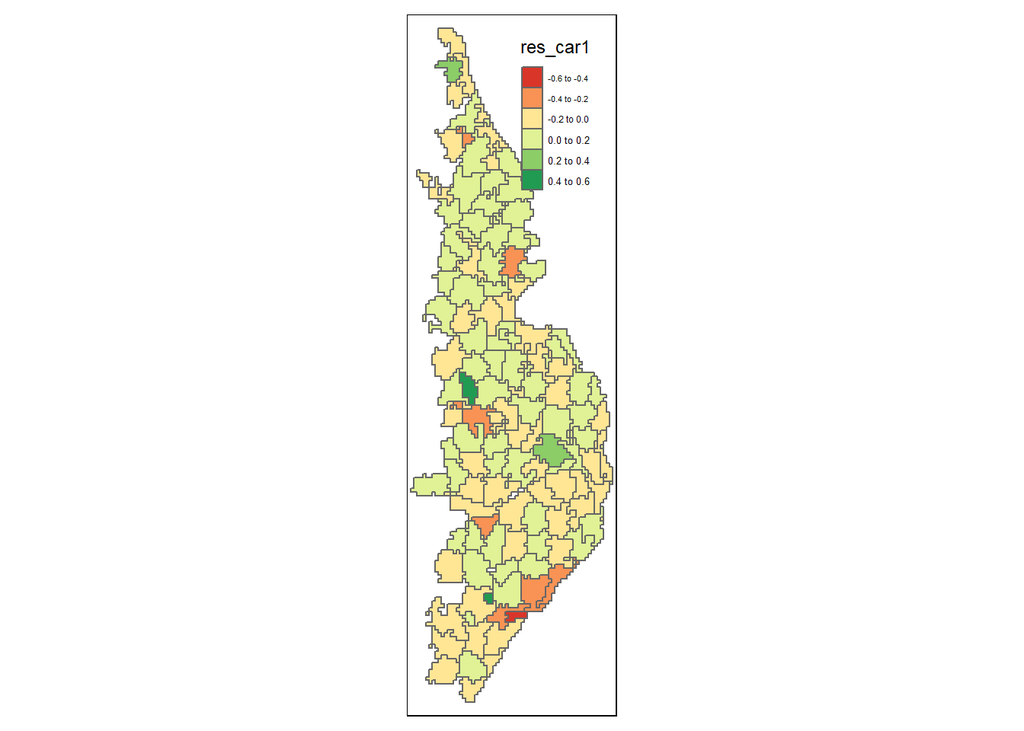

Según Bivand, podría usar el AIC para comparar los modelos. Vemos que el SAR1 es mejor.

```r
print(paste('LM 1:', AIC(lm1)))
```

```
## [1] "LM 1: -115.036309206064"
```

```r
print(paste('SAR 1:', AIC(sar1)))
```

```
## [1] "SAR 1: -128.925411107596"
```

```r
print(paste('CAR 1:', AIC(car1)))
```

```
## [1] "CAR 1: -122.857937497178"
```

El modelo **proper CAR** es el más común y se puede especificar como:

$$\omega(s) \sim MVN(0, \alpha^2[D - \rho W]^{-1}$$

dodne $\alpha^2$ es la varianza espacial. Este modelo implica que la distribución condicional para cada sitio $i$ dada su vecindad es un promedio de los efectos espaciales de sus vecinos, pesados por un parámetro de suavización, $\rho$. Ademas, condicionalmente, la distribución para cada vecino es independiente.

$$\omega(s_i) | \omega(s_j), i \ne j\sim N(\rho \frac{\sum_j{\omega(s_j)}}{N_i}, \frac{\alpha^2}{N_i})$$

Cuando una región tiene pocos vecinos, el $N_i$ sera pequeño, permitiendo que la distribución normal tenga mayor varianza. Cuando tengo muchos vecinos, la incertidumbre disminuye.

Cuando el parametro $\rho$ es cerca de cero, hablo de observaciones independientes, o sea, no hay correlación.

En la librería frecuentista `spaMM` no tengo el modelo anterior, si no:

$$\omega(s) \sim MVN(0, \alpha^2[I_N - \rho W]^{-1}$$

## 5. Modelo mixto con efectos aleatorios

Los errores $e_i$ son los que incorporan la variabilidad entre areas. Estos terminos se conocen a veces como *efectos aleatorios - RE*, porque su valor puede cambiar de area a area, lo que no se espera que suceda con las covariables (que entran en los *efectos fijos - FE*). Es comun usar los RE para modelar interaccion entre observaciones.

Los modelos mixtos se pueden formular como:

$$Y = X\beta + Ze + \varepsilon$$

donde:

- $e$ es el vector de RE y $Z$ les da su estructura. Se asume $e \sim N(0, \Sigma_e)$. $Z$ es una matriz de diseño fija o parametrizada.

Para ajustar los modelos se usa ML o REML. En R usamos los paquetes `nlme` y `lme4`, que nos permiten especificar distintos tipos de matrices de covarianza para los efectos aleatorios.

La parte fija del modelo es la misma formula que venimos usando para los modelos anteriores LM, SAR y CAR. La parte aleatorio debe incluir un efecto aleatorio **por area**. Esto se hace incluyendo una columna que identifique al area en la formula para los RE:

```r
# df$id_unico <- as.factor(df$id_unico)
# mix1 <- lme(
#   fixed = Media_ESPI.LTT ~ Media_DEM + Media_VUT,
#   random = ~ 1 | id_unico,
#   data = df,
#   # correlation = cor_str,
#   method = 'REML'
# )
# data$res_mix1 <- residuals(mix1)
# summary(mix1)
```

```r
# imoran <- moran.mc(x = data$res_mix1, listw = w, nsim = 1000,
#                    zero.policy = T, na.action = na.omit)
# imoran
# qtm(shp = data, fill = 'res_mix1')
```

Ahora ajustemos un modelo mixto usando una matriz de correlación que depende de la distancia entre los centroides de las areas. Primero necesitamos especificar la estructura de correlacion entre areas; en este caso lo hacemos con un semivariograma Gaussiano basado en las distancias euclideas ente centroides.

La funcion `nlme::corSpatial` crea un objeto que contiene una estructura de correlacion espacial. El argumento `type` le dice que tipo de semivariograma tiene que armar. Una vez que el objeto esta construido, para usarlo hay que inicializarlo con `Initialize`.

En mi caso creo que no puedo ajustar porque tengo solo una observación para cada nivel del efecto aleatorio. [http://r-sig-geo.2731867.n2.nabble.com/testing-nlme-models-for-spatial-correlation-td7591354.html]

"Dear Javier,

It looks like you have only one observation for each combination of BLOQUE/ AMBIENTE/ TRATAMIENTO/ SUBMUESTREO. That is an observation level random effect (OLRE) which doesn’t make sense with a Gaussian distribution. The ORLE and the residual would model the exact same thing. Model2 doesn’t make sense."

```r
# structure <- corSpatial(
#   value = 1, # range
#   form = ~ lat + lon, # no termino de entender esto
#   type = 'gaussian'
# )
#
# df <- data.frame(data)
# cor_str <- Initialize(
#   object = structure,
#   data = df[, c('lat', 'lon')],
#   nugget = TRUE
# )
#
# cor_str
# plot(cor_str)
```

```r
# mix2 <- lme(
#   fixed = Media_ESPI.LTT ~ Media_DEM + Media_VUT,
#   random = ~ 1 | id_unico,
#   data = df,
#   correlation = corGaus(value = c(0.1), form = ~ lat + lon, nugget = TRUE),
#   method = 'REML'
# )
# data$res_mix2 <- residuals(mix2)
# summary(mix2)
```

```r
# imoran <- moran.mc(x = data$res_mix2, listw = w, nsim = 1000,
#                    zero.policy = T, na.action = na.omit)
# imoran
# qtm(shp = data, fill = 'res_mix2')
```